# OCE 패키지 소개

2020-09-12T00:21:01+09:00

## 개요

- 새로운 분야에 대한 자료 정리는 언제나 흥미롭다.
- 오늘은 해양과학을 분석해보는 시간을 갖는다.
- 사실 필자는 해양과학을 모른다.

## 교재

- 교재 [Oceanographic Analysis with R](https://www.springer.com/gp/book/9781493988426)는 구매할 수 있다.

[figure not shown]

## 패키지 설치

- [패키지 홈페이지](https://dankelley.github.io/oce/)를 참고한다.
- 패키지 저자는 CRAN에서 다운로드 받는 것 보다는 깃허브에서 받는 것을 추천한다.
  - 패키지 업데이트가 1년에 몇번 되지 않는다고 조금은 솔직하게 말한다.

```r
# install.packages("oce", dependencies = TRUE)
library(oce)
```

## Evolution of oce

- 홈페이지에서 `Oce`는 오픈 소스 시스템으로 소개하고 있기 때문에, 관련 학문에 종사하는 사람들이 참여 해주는 것이 해당 패키지 발전에 매우 중요한 부분이다.

## 그래프

- 간단한 시각화를 구현해보도록 한다.

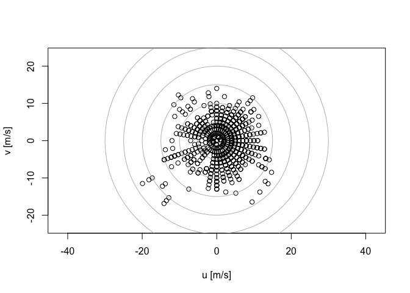

```r
data(buoy, package = "ocedata")
theta <- (90 - buoy$direction) * pi / 180
u <- -buoy$wind*cos(theta)
v <- -buoy$wind*sin(theta)
s <- c(-1, 1) * max(buoy$wind, na.rm = TRUE)
plot(u, v, xlab = "u [m/s]", ylab = "v [m/s]", xlim=s, ylim=s, asp=1)
for (ring in seq(5, 30, 5))
  lines(ring*cos(seq(0, 2*pi, pi/32)),
        ring*sin(seq(0, 2*pi, pi/32)), col="gray")
```

- 엘니뇨 그림을 그려본다.

```r
library(WaveletComp)
data(soi, package = "ocedata")
date <- seq(ISOdatetime(soi$year[1], 1, 1, 0, 0, 0, tz = "UTC"),
            length.out = length(soi$year), by = "1 month")

w <- analyze.wavelet(data.frame(date = date, index = soi$index),
                     "index", dt = 1/12, lowerPeriod = 1)
```

```
## Smoothing the time series...
## Starting wavelet transformation...
## ... and simulations...
##
## Class attributes are accessible through following names:
## series loess.span dt dj Wave Phase Ampl Power Power.avg Power.pval Power.avg.pval Ridge Period Scale nc nr coi.1 coi.2 axis.1 axis.2 date.format date.tz
```

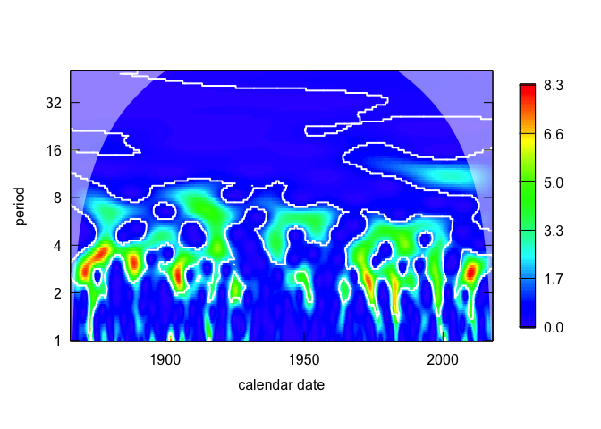

```r
wt.image(w, plot.ridge = FALSE, siglvl = 0.005, color.key = "i", show.date = TRUE)
```

- 이번에는 지도 그래프를 그려본다.

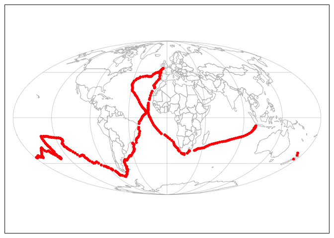

```r
library(oce)
par(mar=rep(0.5, 4))
data(endeavour, package = "ocedata")
data("coastlineWorld")
mapPlot(coastlineWorld, type = "l", fill = "gray")
mapPoints(endeavour$longitude, endeavour$latitude, pch = 20, col = 'red')
```

## OCE 객체

- oce 패키지를 자유롭게 쓰려면, 우선 데이터 객체에 대해 이해를 해야 한다.
  - ctd 객체라고 부르는 것 같다.

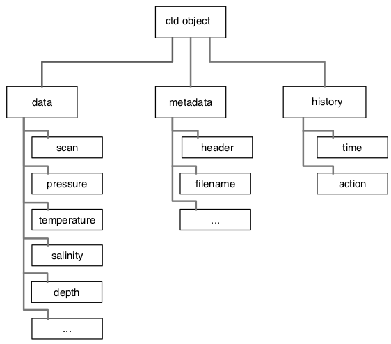

## 요약

- R을 좋아하는 이유중의 하나는 특정 도메인에 맞게 설계된 패키지가 있다는 전문성이며, 패키지에는 반드시 논문 또는 참고할만한 교재를 추천해준다.
- 해양학은 처음 본 분야이지만, 이렇게 쉽게 접근하고 사용할 수 있도록 도와주는 패키지가 있다는 것은 R의 장점이다.

https://www.earthdatascience.org/tags/data-exploration-and-analysis/data-visualization/